# Project: Investigate a Dataset - [No show appointments Database]

- Introduction
- Data Wrangling
- Exploratory Data Analysis
- Conclusions

## Introduction

### Dataset Description:

This dataset describes the Data of patients in a brasillian clinic. Variables include Patient ID, Appointment ID, name, gender and age. It also includes data about their conditions such as diabetes, hypertension, alcoholism and handicaps. It also includes data for whether they showed up for their appointment or not and whether they recieved an sms to confirm the appointment or not.

### Question(s) for Analysis

In this analysis two main questions are answered:

1-What are the variables the affect the patients tendency to show up to the appointment?

2-What are the main prevelant conditions based on a patients age?

```python
#packages imported

import pandas as pd
import numpy as np
import matplotlib.pyplot as plt
import seaborn as sns
%matplotlib inline
from datetime import datetime
```

```python
# Upgrade pandas to use dataframe.explode() function.
#!pip install --upgrade pandas==0.25.0
```

```python
#loading the no show appointments database
df=pd.read_csv(('Database_No_show_appointments/noshowappointments-kagglev2-may-2016.csv'))
df.info()
```

```
<class 'pandas.core.frame.DataFrame'>
RangeIndex: 110527 entries, 0 to 110526
Data columns (total 14 columns):
PatientId         110527 non-null float64
AppointmentID     110527 non-null int64
Gender            110527 non-null object
ScheduledDay      110527 non-null object
AppointmentDay    110527 non-null object
Age               110527 non-null int64
Neighbourhood     110527 non-null object
Scholarship       110527 non-null int64
Hipertension      110527 non-null int64
Diabetes          110527 non-null int64
Alcoholism        110527 non-null int64
Handcap           110527 non-null int64
SMS_received      110527 non-null int64
No-show           110527 non-null object
dtypes: float64(1), int64(8), object(5)
memory usage: 11.8+ MB
```

```python
df.head()
```

|  | PatientId | AppointmentID | Gender | ScheduledDay | AppointmentDay | Age | Neighbourhood | Scholarship | Hipertension | Diabetes | Alcoholism | Handcap | SMS_received | No-show |
| --- | --- | --- | --- | --- | --- | --- | --- | --- | --- | --- | --- | --- | --- | --- |
| 0 | 2.987250e+13 | 5642903 | F | 2016-04-29T18:38:08Z | 2016-04-29T00:00:00Z | 62 | JARDIM DA PENHA | 0 | 1 | 0 | 0 | 0 | 0 | No |
| 1 | 5.589978e+14 | 5642503 | M | 2016-04-29T16:08:27Z | 2016-04-29T00:00:00Z | 56 | JARDIM DA PENHA | 0 | 0 | 0 | 0 | 0 | 0 | No |
| 2 | 4.262962e+12 | 5642549 | F | 2016-04-29T16:19:04Z | 2016-04-29T00:00:00Z | 62 | MATA DA PRAIA | 0 | 0 | 0 | 0 | 0 | 0 | No |
| 3 | 8.679512e+11 | 5642828 | F | 2016-04-29T17:29:31Z | 2016-04-29T00:00:00Z | 8 | PONTAL DE CAMBURI | 0 | 0 | 0 | 0 | 0 | 0 | No |
| 4 | 8.841186e+12 | 5642494 | F | 2016-04-29T16:07:23Z | 2016-04-29T00:00:00Z | 56 | JARDIM DA PENHA | 0 | 1 | 1 | 0 | 0 | 0 | No |

# The following was noticed:

```
AppointmentDay and schedule Day are string and not datetime
No null data (number of entries in all columns are the same as the number of rows)
Several spelling mistakes(such as handcap, hipertension)
No-show is Yes if patient didn't show up and No if patient showed up(known from data descrption) which can cause confusion
```

```python
#Check for number of unique values
df.nunique()
```

```
PatientId          62299
AppointmentID     110527
Gender                 2
ScheduledDay      103549
AppointmentDay        27
Age                  104
Neighbourhood         81
Scholarship            2
Hipertension           2
Diabetes               2
Alcoholism             2
Handcap                5
SMS_received           2
No-show                2
dtype: int64
```

```python
df.describe()
```

|  | PatientId | AppointmentID | Age | Scholarship | Hipertension | Diabetes | Alcoholism | Handcap | SMS_received |
| --- | --- | --- | --- | --- | --- | --- | --- | --- | --- |
| count | 1.105270e+05 | 1.105270e+05 | 110527.000000 | 110527.000000 | 110527.000000 | 110527.000000 | 110527.000000 | 110527.000000 | 110527.000000 |
| mean | 1.474963e+14 | 5.675305e+06 | 37.088874 | 0.098266 | 0.197246 | 0.071865 | 0.030400 | 0.022248 | 0.321026 |
| std | 2.560949e+14 | 7.129575e+04 | 23.110205 | 0.297675 | 0.397921 | 0.258265 | 0.171686 | 0.161543 | 0.466873 |
| min | 3.921784e+04 | 5.030230e+06 | -1.000000 | 0.000000 | 0.000000 | 0.000000 | 0.000000 | 0.000000 | 0.000000 |
| 25% | 4.172614e+12 | 5.640286e+06 | 18.000000 | 0.000000 | 0.000000 | 0.000000 | 0.000000 | 0.000000 | 0.000000 |
| 50% | 3.173184e+13 | 5.680573e+06 | 37.000000 | 0.000000 | 0.000000 | 0.000000 | 0.000000 | 0.000000 | 0.000000 |
| 75% | 9.439172e+13 | 5.725524e+06 | 55.000000 | 0.000000 | 0.000000 | 0.000000 | 0.000000 | 0.000000 | 1.000000 |
| max | 9.999816e+14 | 5.790484e+06 | 115.000000 | 1.000000 | 1.000000 | 1.000000 | 1.000000 | 4.000000 | 1.000000 |

### Data Cleaning

> The following procedures will be done for the data:

> Appointment Day and schedueled date are objects, they will be converted to datetime to make it easier to handle.

> There are no NaN data so no need to drop any rows or replace NaN values

> Duplicates were also checked and there were not any

> Age has a value of -1 and 115 which were not logical and was removed

> Handicap will be combined to be more clear in analysis

> Spelling mistakes in columns such as handcap and hipertension will be corrected

> Data shows the patient as No-show (yes) and show (no), it will be reversed and converted to intiger for easier handling

> Handicap will be combined as either have handicap (1) and no handicap (0) for easier handling

```python
#check for dulplicates
df.duplicated().sum()
```

```
0
```

By looking at age, there is -1 min value and 115 as max value which is not logic, so both will be dropped.

```python
#locate age=-1 value
df.loc[df['Age'] == -1]
```

|  | PatientId | AppointmentID | Gender | ScheduledDay | AppointmentDay | Age | Neighbourhood | Scholarship | Hipertension | Diabetes | Alcoholism | Handcap | SMS_received | No-show |
| --- | --- | --- | --- | --- | --- | --- | --- | --- | --- | --- | --- | --- | --- | --- |
| 99832 | 4.659432e+14 | 5775010 | F | 2016-06-06T08:58:13Z | 2016-06-06T00:00:00Z | -1 | ROMÃO | 0 | 0 | 0 | 0 | 0 | 0 | No |

```python
#drop Age=-1 value
df.drop([99832], inplace=True)
```

```python
#confirming that age=-1 value is removed
df.describe()
```

|  | PatientId | AppointmentID | Age | Scholarship | Hipertension | Diabetes | Alcoholism | Handcap | SMS_received |
| --- | --- | --- | --- | --- | --- | --- | --- | --- | --- |
| count | 1.105260e+05 | 1.105260e+05 | 110526.000000 | 110526.000000 | 110526.000000 | 110526.000000 | 110526.000000 | 110526.000000 | 110526.000000 |
| mean | 1.474934e+14 | 5.675304e+06 | 37.089219 | 0.098266 | 0.197248 | 0.071865 | 0.030400 | 0.022248 | 0.321029 |
| std | 2.560943e+14 | 7.129544e+04 | 23.110026 | 0.297676 | 0.397923 | 0.258266 | 0.171686 | 0.161543 | 0.466874 |
| min | 3.921784e+04 | 5.030230e+06 | 0.000000 | 0.000000 | 0.000000 | 0.000000 | 0.000000 | 0.000000 | 0.000000 |
| 25% | 4.172536e+12 | 5.640285e+06 | 18.000000 | 0.000000 | 0.000000 | 0.000000 | 0.000000 | 0.000000 | 0.000000 |
| 50% | 3.173184e+13 | 5.680572e+06 | 37.000000 | 0.000000 | 0.000000 | 0.000000 | 0.000000 | 0.000000 | 0.000000 |
| 75% | 9.438963e+13 | 5.725523e+06 | 55.000000 | 0.000000 | 0.000000 | 0.000000 | 0.000000 | 0.000000 | 1.000000 |
| max | 9.999816e+14 | 5.790484e+06 | 115.000000 | 1.000000 | 1.000000 | 1.000000 | 1.000000 | 4.000000 | 1.000000 |

```python
#locating  age=115 as it is too high and unrealistic
df.loc[df['Age'] ==115]
```

|  | PatientId | AppointmentID | Gender | ScheduledDay | AppointmentDay | Age | Neighbourhood | Scholarship | Hipertension | Diabetes | Alcoholism | Handcap | SMS_received | No-show |
| --- | --- | --- | --- | --- | --- | --- | --- | --- | --- | --- | --- | --- | --- | --- |
| 63912 | 3.196321e+13 | 5700278 | F | 2016-05-16T09:17:44Z | 2016-05-19T00:00:00Z | 115 | ANDORINHAS | 0 | 0 | 0 | 0 | 1 | 0 | Yes |
| 63915 | 3.196321e+13 | 5700279 | F | 2016-05-16T09:17:44Z | 2016-05-19T00:00:00Z | 115 | ANDORINHAS | 0 | 0 | 0 | 0 | 1 | 0 | Yes |
| 68127 | 3.196321e+13 | 5562812 | F | 2016-04-08T14:29:17Z | 2016-05-16T00:00:00Z | 115 | ANDORINHAS | 0 | 0 | 0 | 0 | 1 | 0 | Yes |
| 76284 | 3.196321e+13 | 5744037 | F | 2016-05-30T09:44:51Z | 2016-05-30T00:00:00Z | 115 | ANDORINHAS | 0 | 0 | 0 | 0 | 1 | 0 | No |
| 97666 | 7.482346e+14 | 5717451 | F | 2016-05-19T07:57:56Z | 2016-06-03T00:00:00Z | 115 | SÃO JOSÉ | 0 | 1 | 0 | 0 | 0 | 1 | No |

```python
#Removing  age=115 value and confirming it is removed
df.drop([63912,63915,68127,76284,97666], inplace=True)
df.describe()
```

|  | PatientId | AppointmentID | Age | Scholarship | Hipertension | Diabetes | Alcoholism | Handcap | SMS_received |
| --- | --- | --- | --- | --- | --- | --- | --- | --- | --- |
| count | 1.105210e+05 | 1.105210e+05 | 110521.000000 | 110521.000000 | 110521.000000 | 110521.000000 | 110521.000000 | 110521.000000 | 110521.000000 |
| mean | 1.474921e+14 | 5.675304e+06 | 37.085694 | 0.098271 | 0.197248 | 0.071869 | 0.030401 | 0.022213 | 0.321034 |
| std | 2.560928e+14 | 7.129576e+04 | 23.104606 | 0.297682 | 0.397923 | 0.258272 | 0.171690 | 0.161440 | 0.466876 |
| min | 3.921784e+04 | 5.030230e+06 | 0.000000 | 0.000000 | 0.000000 | 0.000000 | 0.000000 | 0.000000 | 0.000000 |
| 25% | 4.172457e+12 | 5.640285e+06 | 18.000000 | 0.000000 | 0.000000 | 0.000000 | 0.000000 | 0.000000 | 0.000000 |
| 50% | 3.172598e+13 | 5.680569e+06 | 37.000000 | 0.000000 | 0.000000 | 0.000000 | 0.000000 | 0.000000 | 0.000000 |
| 75% | 9.438963e+13 | 5.725523e+06 | 55.000000 | 0.000000 | 0.000000 | 0.000000 | 0.000000 | 0.000000 | 1.000000 |
| max | 9.999816e+14 | 5.790484e+06 | 102.000000 | 1.000000 | 1.000000 | 1.000000 | 1.000000 | 4.000000 | 1.000000 |

```python
#converting appointment day to datetime instead of string
df['AppointmentDay']=pd.to_datetime(df['AppointmentDay'])
```

```python
#converting schedueled day to datetime instead of string
df['ScheduledDay']=pd.to_datetime(df['ScheduledDay'])
```

```python
#dropping appointment ID
df.drop(columns=['AppointmentID'], axis = 1, inplace = True)
```

```python
#Replacing yes and no in No Show column with 0 and 1 respectively for data consistency in the dataframe (0: patient didn't show, 1 patient showed)
df['No-show']=df['No-show'].replace('No',1)
df['No-show']=df['No-show'].replace('Yes',0)
```

```python
# Renaming misspelled columns and no-show to Patient_show_up to be more clear
df.rename(columns={'Hipertension':'Hypertension'}, inplace=True)
df.rename(columns={'Handcap':'Handicap'}, inplace=True)
df.rename(columns={'No-show':'Patient_show_up'}, inplace=True)
```

```python
#combining handicap condition as present or absent for better comparison
df['Handicap_combined'] = df['Handicap'].astype('bool')
df['Handicap_combined'].value_counts()
```

```
False    108284
True       2237
Name: Handicap_combined, dtype: int64
```

```python
#changing data type to int to be more consistant with other columns
df['Handicap_combined'] = df['Handicap_combined'].astype('int')
df['Handicap_combined'].value_counts()
```

```
0    108284
1      2237
Name: Handicap_combined, dtype: int64
```

```python
#checking that data are in the integer form and present in only 0 and 1 values in selected columns for consistency
int_columns=['Scholarship','Hypertension','Alcoholism','Diabetes','Handicap_combined','SMS_received','Patient_show_up']

for column in df[int_columns]:
    print(df[column].value_counts())
    print('\n')
```

```
0    99660
1    10861
Name: Scholarship, dtype: int64


0    88721
1    21800
Name: Hypertension, dtype: int64


0    107161
1      3360
Name: Alcoholism, dtype: int64


0    102578
1      7943
Name: Diabetes, dtype: int64


0    108284
1      2237
Name: Handicap_combined, dtype: int64


0    75040
1    35481
Name: SMS_received, dtype: int64


1    88205
0    22316
Name: Patient_show_up, dtype: int64
```

It is confirmed now that the data are all present as either 0 for False and 1 for True in integer form.

```python
df.info()
```

```
<class 'pandas.core.frame.DataFrame'>
Int64Index: 110521 entries, 0 to 110526
Data columns (total 14 columns):
PatientId            110521 non-null float64
Gender               110521 non-null object
ScheduledDay         110521 non-null datetime64[ns]
AppointmentDay       110521 non-null datetime64[ns]
Age                  110521 non-null int64
Neighbourhood        110521 non-null object
Scholarship          110521 non-null int64
Hypertension         110521 non-null int64
Diabetes             110521 non-null int64
Alcoholism           110521 non-null int64
Handicap             110521 non-null int64
SMS_received         110521 non-null int64
Patient_show_up      110521 non-null int64
Handicap_combined    110521 non-null int64
dtypes: datetime64[ns](2), float64(1), int64(9), object(2)
memory usage: 12.6+ MB
```

```python
df.head()
```

|  | PatientId | Gender | ScheduledDay | AppointmentDay | Age | Neighbourhood | Scholarship | Hypertension | Diabetes | Alcoholism | Handicap | SMS_received | Patient_show_up | Handicap_combined |
| --- | --- | --- | --- | --- | --- | --- | --- | --- | --- | --- | --- | --- | --- | --- |
| 0 | 2.987250e+13 | F | 2016-04-29 18:38:08 | 2016-04-29 | 62 | JARDIM DA PENHA | 0 | 1 | 0 | 0 | 0 | 0 | 1 | 0 |
| 1 | 5.589978e+14 | M | 2016-04-29 16:08:27 | 2016-04-29 | 56 | JARDIM DA PENHA | 0 | 0 | 0 | 0 | 0 | 0 | 1 | 0 |
| 2 | 4.262962e+12 | F | 2016-04-29 16:19:04 | 2016-04-29 | 62 | MATA DA PRAIA | 0 | 0 | 0 | 0 | 0 | 0 | 1 | 0 |
| 3 | 8.679512e+11 | F | 2016-04-29 17:29:31 | 2016-04-29 | 8 | PONTAL DE CAMBURI | 0 | 0 | 0 | 0 | 0 | 0 | 1 | 0 |
| 4 | 8.841186e+12 | F | 2016-04-29 16:07:23 | 2016-04-29 | 56 | JARDIM DA PENHA | 0 | 1 | 1 | 0 | 0 | 0 | 1 | 0 |

## Descriptive Charts for Data

### NB: For all charts, 0 represents False (condition is absent) and 1 represents True (conidtion is present)

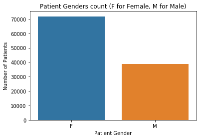

```python
#Plot bar charts
sns.countplot(data = df, x = 'Gender')
plt.title('Patient Genders count (F for Female, M for Male)')
plt.xlabel('Patient Gender')
plt.ylabel('Number of Patients');
```

```
Text(0,0.5,'Number of Patients')
```

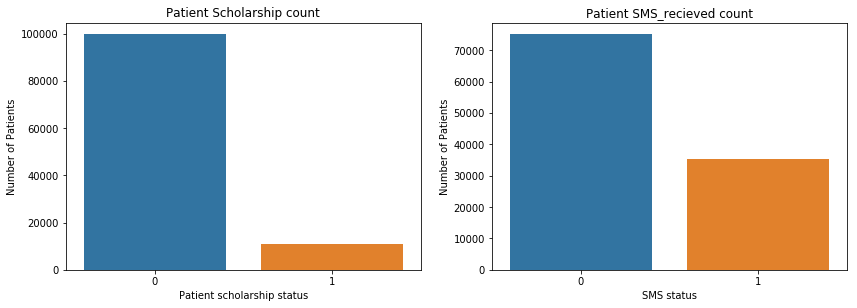

```python
plt.figure(figsize = [14, 10])

# Scholarship
plt.subplot(2, 2, 1)
sns.countplot(data = df, x = 'Scholarship')
plt.title('Patient Scholarship count')
plt.xlabel('Patient scholarship status')
plt.ylabel('Number of Patients')

# SMS_recieved
plt.subplot(2, 2, 2)
sns.countplot(data = df, x = 'SMS_received')
plt.title('Patient SMS_recieved count')
plt.xlabel('SMS status')
plt.ylabel('Number of Patients')
```

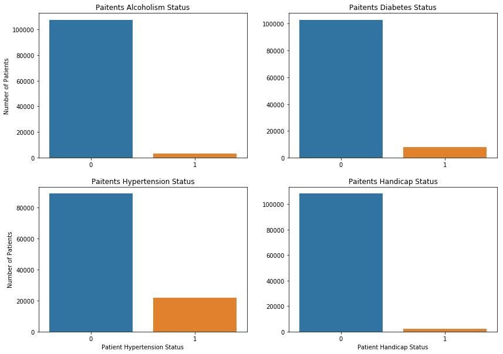

```python
plt.figure(figsize = [14, 10])

# alcoholism
plt.subplot(2, 2, 1)
sns.countplot(data = df, x = 'Alcoholism')
plt.title('Paitents Alcoholism Status')
plt.xlabel('')
plt.ylabel('Number of Patients')

# diabetes
plt.subplot(2, 2, 2)
sns.countplot(data = df, x = 'Diabetes')
plt.title('Paitents Diabetes Status')
plt.xlabel('')
plt.ylabel('');

# hypertension
plt.subplot(2, 2, 3)
sns.countplot(data = df, x = 'Hypertension')
plt.title('Paitents Hypertension Status')
plt.xlabel('Patient Hypertension Status')
plt.ylabel('Number of Patients');

# handicap
plt.subplot(2, 2, 4)
sns.countplot(data = df, x = 'Handicap_combined')
plt.title('Paitents Handicap Status')
plt.xlabel('Patient Handicap Status')
plt.ylabel('');
```

As shown above, most of the patients are females with no scholarships and most of them did not recieve an SMS. Also, Most of the patients don't suffer from any health conditions (handicap, alcoholism, hypertension or diabetes).

```python
df.describe()
```

|  | PatientId | Age | Scholarship | Hypertension | Diabetes | Alcoholism | Handicap | SMS_received | Patient_show_up | Handicap_combined |
| --- | --- | --- | --- | --- | --- | --- | --- | --- | --- | --- |
| count | 1.105210e+05 | 110521.000000 | 110521.000000 | 110521.000000 | 110521.000000 | 110521.000000 | 110521.000000 | 110521.000000 | 110521.000000 | 110521.000000 |
| mean | 1.474921e+14 | 37.085694 | 0.098271 | 0.197248 | 0.071869 | 0.030401 | 0.022213 | 0.321034 | 0.798084 | 0.020240 |
| std | 2.560928e+14 | 23.104606 | 0.297682 | 0.397923 | 0.258272 | 0.171690 | 0.161440 | 0.466876 | 0.401432 | 0.140823 |
| min | 3.921784e+04 | 0.000000 | 0.000000 | 0.000000 | 0.000000 | 0.000000 | 0.000000 | 0.000000 | 0.000000 | 0.000000 |
| 25% | 4.172457e+12 | 18.000000 | 0.000000 | 0.000000 | 0.000000 | 0.000000 | 0.000000 | 0.000000 | 1.000000 | 0.000000 |
| 50% | 3.172598e+13 | 37.000000 | 0.000000 | 0.000000 | 0.000000 | 0.000000 | 0.000000 | 0.000000 | 1.000000 | 0.000000 |
| 75% | 9.438963e+13 | 55.000000 | 0.000000 | 0.000000 | 0.000000 | 0.000000 | 0.000000 | 1.000000 | 1.000000 | 0.000000 |
| max | 9.999816e+14 | 102.000000 | 1.000000 | 1.000000 | 1.000000 | 1.000000 | 4.000000 | 1.000000 | 1.000000 | 1.000000 |

## Exploratory Data Analysis

### Research Question 1 (what are the variables affecting patients tendency to show up to their appointments?)

```python
#Percentage of patients showing up to not showing up
show_up_sum = df["Patient_show_up"].value_counts()
show_up_sum
```

```
1    88205
0    22316
Name: Patient_show_up, dtype: int64
```

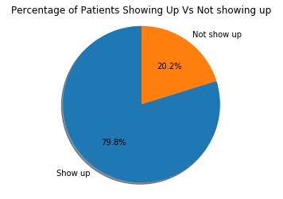

```python
fig1, ax1 = plt.subplots()
labels='Show up','Not show up'
ax1.pie(show_up_sum, labels=labels, autopct='%1.1f%%',
        shadow=True, startangle=90)
plt.title('Percentage of Patients Showing Up Vs Not showing up')
ax1.axis('equal')

plt.show()
```

79.8% or approximately 80% of the patients show up to the appointment. Now we will take a closer look on the percentage of patients showing up for each variable.

```python
#Percentage of patients showing up based on gender
show_up_gender = df.groupby('Gender').Patient_show_up.mean()*100
show_up_gender
```

```
Gender
F    79.687892
M    80.032052
Name: Patient_show_up, dtype: float64
```

Based on gender: percentage of males showing up and percentage of females showing up, we see 79% of female patients show up and 80% of male patients show up, Thus the gender does not affect the tendency for patients to show up to their appointment

```
Text(0,0.5,'Patients showing up (%)')
```

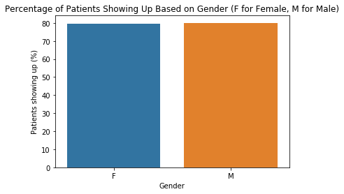

```python
sns.barplot(data = df, x = show_up_gender.index, y=show_up_gender)
plt.title('Percentage of Patients Showing Up Based on Gender (F for Female, M for Male)')
plt.ylabel('Patients showing up (%)')
```

```python
show_up_sms = df.groupby('SMS_received').Patient_show_up.mean()*100
show_up_sms
```

```
SMS_received
0    83.299574
1    72.424678
Name: Patient_show_up, dtype: float64
```

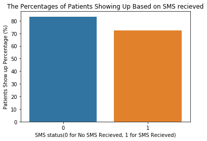

```python
sns.barplot(data = df, x = show_up_sms.index, y=show_up_sms)
plt.title('The Percentages of Patients Showing Up Based on SMS recieved')
plt.ylabel('Patients Show up Percentage (%)');
plt.xlabel('SMS status(0 for No SMS Recieved, 1 for SMS Recieved)');
```

```python
show_up_alc= df.groupby('Alcoholism').Patient_show_up.mean()*100
show_up_alc
```

```
Alcoholism
0    79.807019
1    79.851190
Name: Patient_show_up, dtype: float64
```

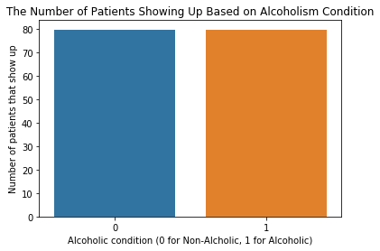

```python
sns.barplot(x = show_up_alc.index, y = show_up_alc)
plt.title('The Number of Patients Showing Up Based on Alcoholism Condition')
plt.xlabel('Alcoholic condition (0 for Non-Alcholic, 1 for Alcoholic)')
plt.ylabel('Number of patients that show up');
```

Based on alcoholism: percentage of alcoholics and non alcoholics showing up is the same (79%) which is close to the general patients showing percentage up at 80%, Thus alcoholism condition does not affect the tendency for patients to show up to their appointment

```python
show_up_handicap_per= df.groupby('Handicap_combined').Patient_show_up.mean()*100
show_up_handicap_per
```

```
Handicap_combined
0    79.764323
1    81.940098
Name: Patient_show_up, dtype: float64
```

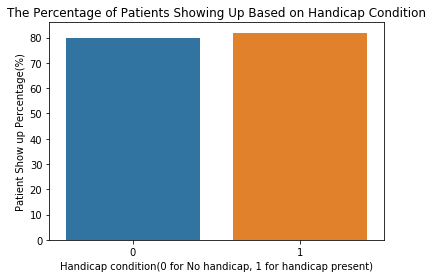

```python
sns.barplot(x = show_up_handicap_per.index, y= show_up_handicap_per)
plt.title('The Percentage of Patients Showing Up Based on Handicap Condition')
plt.xlabel('Handicap condition(0 for No handicap, 1 for handicap present)')
plt.ylabel('Patient Show up Percentage(%)');
```

Based on Handicap condition: percentage of non handicapped and handicapped showing up almost the same at 79% and 81% respectively. which is close to the general patients showing percentage up at 80%, Thus this condition does not affect the tendency for patients to show up to their appointment

```python
show_up_scholarship= df.groupby('Scholarship').Patient_show_up.mean()*100
show_up_scholarship
```

```
Scholarship
0    80.194662
1    76.263696
Name: Patient_show_up, dtype: float64
```

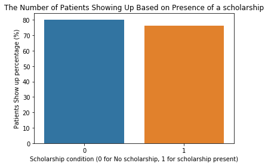

```python
sns.barplot(x = show_up_scholarship.index, y= show_up_scholarship)
plt.title('The Number of Patients Showing Up Based on Presence of a scholarship')
plt.xlabel('Scholarship condition (0 for No scholarship, 1 for scholarship present)')
plt.ylabel('Patients Show up percentage (%)');
```

Based on scholarship: percentage of scholarship holders (76%) showing up is lower by 4% than non scholarship holders showing up (80%). However, both areclose to the general patients showing percentage up at 80%, Thus alcoholism condition does not affect the tendency for patients to show up to their appointment

```python
show_up_diabetes= df.groupby('Diabetes').Patient_show_up.mean()*100
show_up_diabetes
```

```
Diabetes
0    79.638909
1    81.996727
Name: Patient_show_up, dtype: float64
```

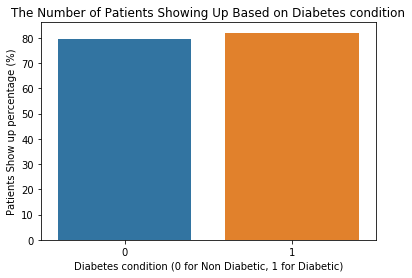

```python
sns.barplot(x = show_up_diabetes.index, y= show_up_diabetes)
plt.title('The Number of Patients Showing Up Based on Diabetes condition')
plt.xlabel('Diabetes condition (0 for Non Diabetic, 1 for Diabetic)')
plt.ylabel('Patients Show up percentage (%)');
```

Based on Diabetes condition: percentage of non diabetics and diabetics showing up almost the same at 79% and 81% respectively. which is close to the general patients showing percentage up at 80%, Thus this condition does not affect the tendency for patients to show up to their appointment

```python
show_up_hypertension= df.groupby('Hypertension').Patient_show_up.mean()*100
show_up_hypertension
```

```
Hypertension
0    79.098522
1    82.697248
Name: Patient_show_up, dtype: float64
```

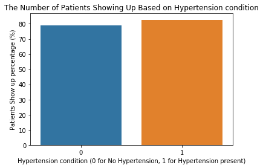

```python
sns.barplot(x = show_up_hypertension.index, y= show_up_hypertension)
plt.title('The Number of Patients Showing Up Based on Hypertension condition')
plt.xlabel('Hypertension condition (0 for No Hypertension, 1 for Hypertension present)')
plt.ylabel('Patients Show up percentage (%)');
```

Based on hypertension condition: percentage of non hypertesive patients and hypertensive patients showing up almost the same at 79% and 82% respectively. which is close to the general patients showing percentage up at 80%, Thus this condition does not affect the tendency for patients to show up to their appointment

So, Based on the above data, around 80% of the patients show up as opposed to 20% not showing up. This percentage is approximately prevalent regardless of gender, scholarship or disease condition.However in case of recieved SMS, patients that did not recieve an SMS tended to show more than patients who did not recieve an SMS.

## Research Question 2: Is there a relationship between Age and different disease conditions?

First patientID duplicates will be removed to analyze data for unique patients

```python
#drop duplicate patient ID
df1=df.drop_duplicates(subset ="PatientId")
df1.info()
```

```
<class 'pandas.core.frame.DataFrame'>
Int64Index: 62296 entries, 0 to 110524
Data columns (total 14 columns):
PatientId            62296 non-null float64
Gender               62296 non-null object
ScheduledDay         62296 non-null datetime64[ns]
AppointmentDay       62296 non-null datetime64[ns]
Age                  62296 non-null int64
Neighbourhood        62296 non-null object
Scholarship          62296 non-null int64
Hypertension         62296 non-null int64
Diabetes             62296 non-null int64
Alcoholism           62296 non-null int64
Handicap             62296 non-null int64
SMS_received         62296 non-null int64
Patient_show_up      62296 non-null int64
Handicap_combined    62296 non-null int64
dtypes: datetime64[ns](2), float64(1), int64(9), object(2)
memory usage: 7.1+ MB
```

```python
df1.describe()
```

|  | PatientId | Age | Scholarship | Hypertension | Diabetes | Alcoholism | Handicap | SMS_received | Patient_show_up | Handicap_combined |
| --- | --- | --- | --- | --- | --- | --- | --- | --- | --- | --- |
| count | 6.229600e+04 | 62296.000000 | 62296.000000 | 62296.000000 | 62296.000000 | 62296.000000 | 62296.000000 | 62296.000000 | 62296.000000 | 62296.000000 |
| mean | 1.471582e+14 | 36.702983 | 0.092911 | 0.196497 | 0.070887 | 0.024175 | 0.020098 | 0.327356 | 0.804289 | 0.018171 |
| std | 2.549003e+14 | 23.527271 | 0.290310 | 0.397352 | 0.256639 | 0.153593 | 0.155010 | 0.469252 | 0.396750 | 0.133572 |
| min | 3.921784e+04 | 0.000000 | 0.000000 | 0.000000 | 0.000000 | 0.000000 | 0.000000 | 0.000000 | 0.000000 | 0.000000 |
| 25% | 4.176895e+12 | 17.000000 | 0.000000 | 0.000000 | 0.000000 | 0.000000 | 0.000000 | 0.000000 | 1.000000 | 0.000000 |
| 50% | 3.198294e+13 | 36.000000 | 0.000000 | 0.000000 | 0.000000 | 0.000000 | 0.000000 | 0.000000 | 1.000000 | 0.000000 |
| 75% | 9.484711e+13 | 56.000000 | 0.000000 | 0.000000 | 0.000000 | 0.000000 | 0.000000 | 1.000000 | 1.000000 | 0.000000 |
| max | 9.999816e+14 | 102.000000 | 1.000000 | 1.000000 | 1.000000 | 1.000000 | 4.000000 | 1.000000 | 1.000000 | 1.000000 |

```
Text(0,0.5,'Number of Patients')
```

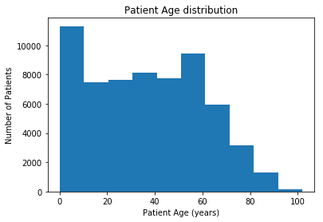

```python
plt.hist(data = df1, x = 'Age')
plt.title('Patient Age distribution')
plt.xlabel('Patient Age (years)')
plt.ylabel('Number of Patients')
```

By examining the figure above after removing duplicate patients, children are the highest number of patients and after 60, number of patients start to decline probably due to old age and mortalility.

Mean Age for each condition will be calculated as below

```python
#creating mean age per condition list
conditions_age={}
conditions_age['Hypertension'] = (df1.groupby('Hypertension').Age.mean().loc[1])
conditions_age['Diabetes'] = (df1.groupby('Diabetes').Age.mean().loc[1])
conditions_age['Handicap_combined'] = (df1.groupby('Handicap_combined').Age.mean().loc[1])
conditions_age['Alcoholism'] = (df1.groupby('Alcoholism').Age.mean().loc[1])
conditions_age
```

```
{'Hypertension': 61.122048852217958,
 'Diabetes': 61.719429347826086,
 'Handicap_combined': 52.580388692579504,
 'Alcoholism': 49.45617529880478}
```

```python
# convert the dictionary to a pandas series
conditions_age_series = pd.Series(conditions_age)
conditions_age_series
```

```
Hypertension         61.122049
Diabetes             61.719429
Handicap_combined    52.580389
Alcoholism           49.456175
dtype: float64
```

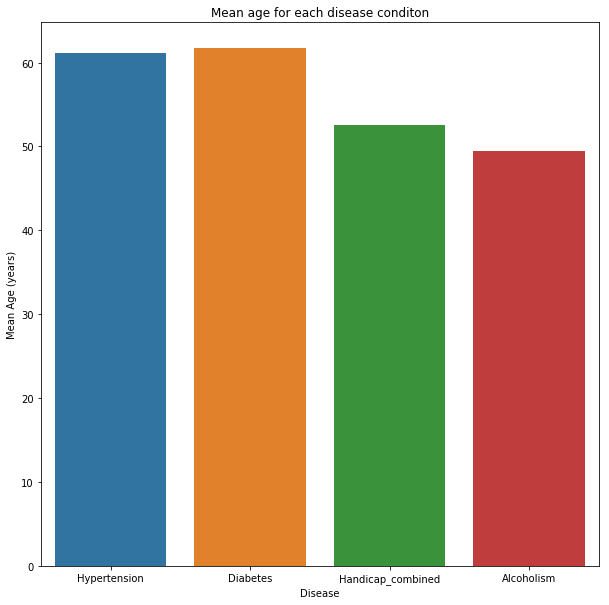

```python
plt.figure(figsize = [10, 10])
sns.barplot(x = conditions_age_series.index, y= conditions_age_series)
plt.title('Mean age for each disease conditon')
plt.xlabel('Disease')
plt.ylabel('Mean Age (years)');
```

> By examining the mean ages of patients for each condition, we can infere that the mean age for patients with hypertension is 61 years, diabetes is also 61 years, handicap is 52 years and alcoholism is 49 years.

### Relationship between Age and Hypertension

```python
#calculating hypertension cases per age
age_hypertension=df.groupby('Age').Hypertension.sum()
age_hypertension
```

```
Age
0        0
1        0
2        0
3        0
4        1
5        0
6        0
7        4
8        1
9        2
10       1
11       0
12       3
13       4
```

[output cut: 48 more lines]

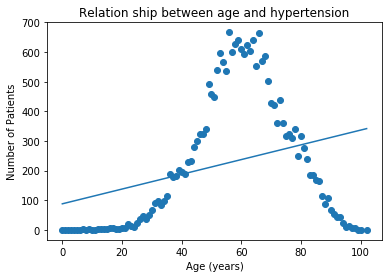

```python
# Drawing scatter plot with added regression line
x=age_hypertension.index
y=age_hypertension
plt.scatter(x = age_hypertension.index, y= age_hypertension)
plt.title('Relation ship between age and hypertension')
plt.xlabel('Age (years)')
plt.ylabel('Number of Patients');

m, b = np.polyfit(x, y, 1)
plt.plot(x, m*x + b)
```

### Relationship between Diabetes and age:

```python
#calculating diabetes cases per age
age_diabetes=df.groupby('Age').Diabetes.sum()
age_diabetes
```

```
Age
0        0
1        1
2        1
3        0
4        1
5        0
6        0
7        3
8        0
9        2
10       3
11       3
12       5
13       0
```

[output cut: 48 more lines]

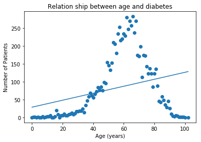

```python
# Drawing scatter plot with added regression line
x = age_diabetes.index
y= age_diabetes
plt.scatter(x = age_diabetes.index, y= age_diabetes)
plt.title('Relation ship between age and diabetes')
plt.xlabel('Age (years)')
plt.ylabel('Number of Patients');
m, b = np.polyfit(x, y, 1)
plt.plot(x, m*x + b)
```

### Relationship between Handicap status and age:

```python
#calculating handicap cases per age
age_handicap=df.groupby('Age').Handicap_combined.sum()
age_handicap
```

```
Age
0       1
1       1
2       1
3       0
4       7
5       4
6       9
7       8
8       8
9      26
10      9
11     10
12     14
13     36
```

[output cut: 48 more lines]

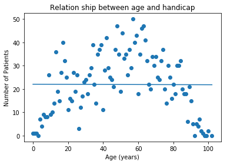

```python
# Drawing scatter plot with added regression line
x = age_handicap.index
y= age_handicap
plt.scatter(x = x, y= y)
plt.title('Relation ship between age and handicap')
plt.xlabel('Age (years)')
plt.ylabel('Number of Patients');
m, b = np.polyfit(x, y, 1)
plt.plot(x, m*x + b)
```

### Relationship between Alcoholism and age:

```python
#calculating alcoholism cases per age
age_alcoholism=df.groupby('Age').Alcoholism.sum()
age_alcoholism
```

```
Age
0       0
1       0
2       0
3       0
4       1
5       1
6       0
7       2
8       1
9       0
10      0
11      1
12      7
13      2
```

[output cut: 48 more lines]

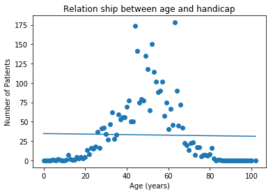

```python
# Drawing scatter plot with added regression line
x = age_alcoholism.index
y= age_alcoholism
plt.scatter(x = x, y= y)
plt.title('Relation ship between age and handicap')
plt.xlabel('Age (years)')
plt.ylabel('Number of Patients');
m, b = np.polyfit(x, y, 1)
plt.plot(x, m*x + b)
```

## Conclusions

### 2 Questions were answered:

#### 1) what are the variables affecting patients tendency to show up to their appointments?

> In summary,approximately 80% of the patients show up to their appointment regardless of their gender, scholarship or condition. Also recieveing SMS did not increase the show up percentage.

#### 2) Are disease conditions affected by patient's age?

> By examining the mean ages of patients for each condition, we can infere that the mean age for patients with hypertension is 61 years, diabetes is also 61 years, handicap is 52 years and alcoholism is 49 years.

### Limitations

> This data is only based in one clinic, it could have been more representative if it was spread out on several clinics or for different countries., The data is also from 2016, it would have been more representative if it is more recent or covered a longer period of time.

```python
from subprocess import call
call(['python', '-m', 'nbconvert', 'Investigate_a_Dataset.ipynb'])
```

```
0
```